# Week 4 - Clustering and classification

## K-means

Reload boston and standardize.

```r
boston <- MASS::Boston

boston <- scale(boston)

# Get pairwise distances
boston.d <- dist(boston, method = "euclidean")
```

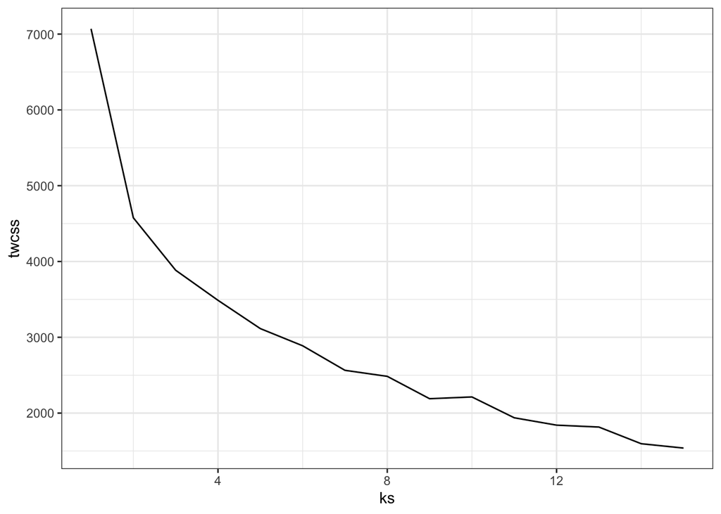

```r
# Test different number of clusters
ks <- 1:15

# Determine optimal number of cluster by total within cluster
# sum of squares

# We run k-means on the scaled data and not on the distances,
# since k-means is not applicable on distance matrix alone, see e.g.
# https://stackoverflow.com/questions/43512808/ and
# https://stats.stackexchange.com/questions/32925/
twcss <- sapply(ks, function(x) { kmeans(boston, centers = x)$tot.withinss})

# Plot
qplot(x = ks, y = twcss, geom = "line") + theme_bw()
```

Well, it is difficult to see what is the optimal number of clusters. Three or four is probably OK, two likely not large enough. Let’s run a (classical) multidimensional scaling in 2D on the distance matrix and see if there are clear clusters

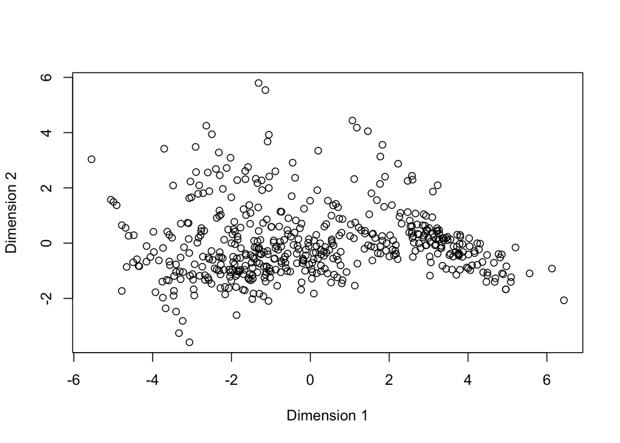

```r
mds.fit <- cmdscale(boston.d, k = 2)

plot(mds.fit[, 1], mds.fit[, 2],
     xlab = "Dimension 1", ylab = "Dimension 2")
```

Well, it seems like there are two clusters in MDS.

Let’s do a k-medoid on the distance matrix

```r
library(cluster)
library(factoextra)
```

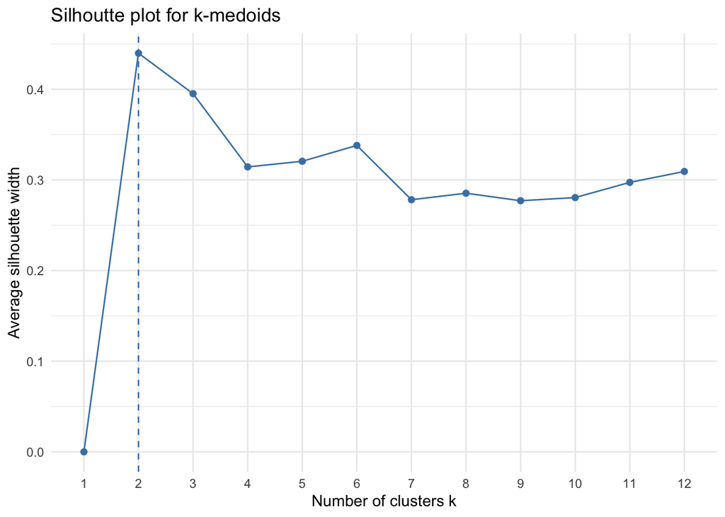

```r
# adapted from https://www.r-bloggers.com/2019/01/10-tips-for-choosing-the-optimal-number-of-clusters/

fviz_nbclust(as.matrix(boston.d), pam, method = "silhouette", k.max = 12) +
  theme_minimal() + ggtitle("Silhoutte plot for k-medoids")
```

With k-medoids, we get two clusters as optimal.

Finally, plot dendrogram

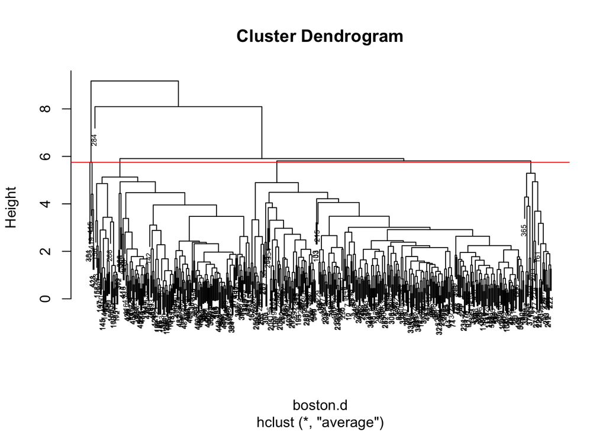

```r
# Choose average clustering as a "generic" one
hier.clust <-  hclust(boston.d, method = "average")
plot(hier.clust, cex = 0.5)
abline(h = 5.75, col = "red")
```

Hierarchical clustering suggests three big clusters and one or two smaller ones.

Since in k-means we noted that 3-4 clusters could be good, decrease the number to 3 based on the short analysis with MDS, k-medoids and hclust.

Let’s visualize the results

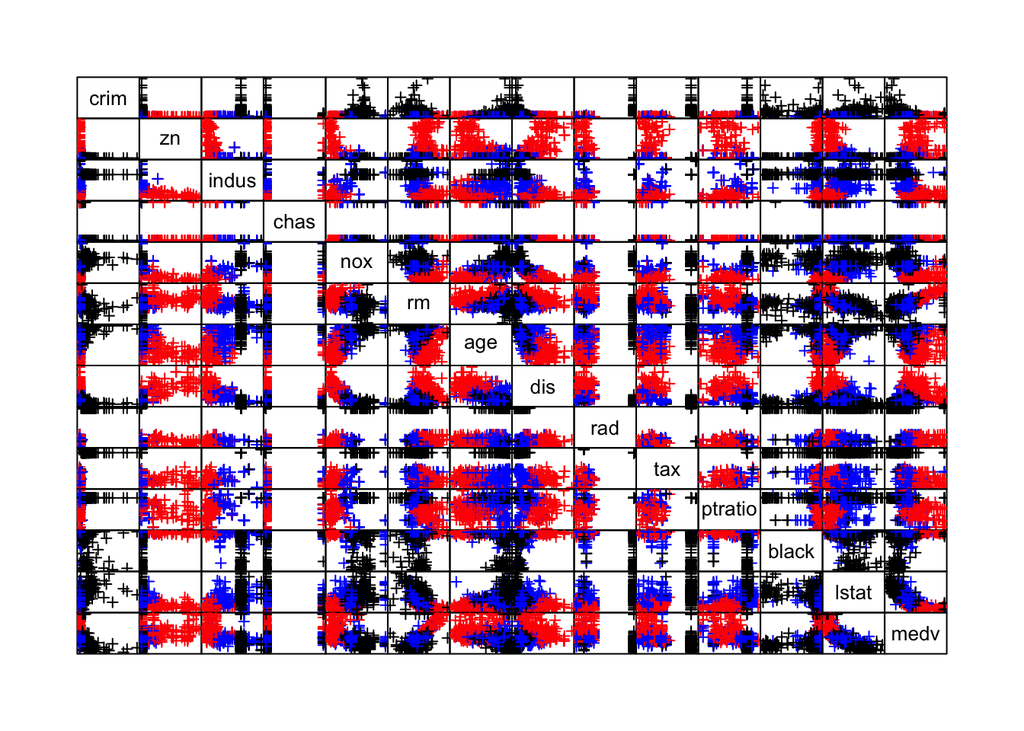

```r
km <- kmeans(boston, centers = 3)

cols <- rep("black", nrow(boston))
cols[km$cluster == 2] <- "blue"
cols[km$cluster == 3] <- "red"

# make more compact, hide axes
pairs(boston, col = cols,
      gap = 0, xaxt = "n", yaxt = "n", pch = 3)
```

Pairs plot does not support the hypothesis of three clusters, although there are clearly many plots with two groups e.g. with `rad` variable.

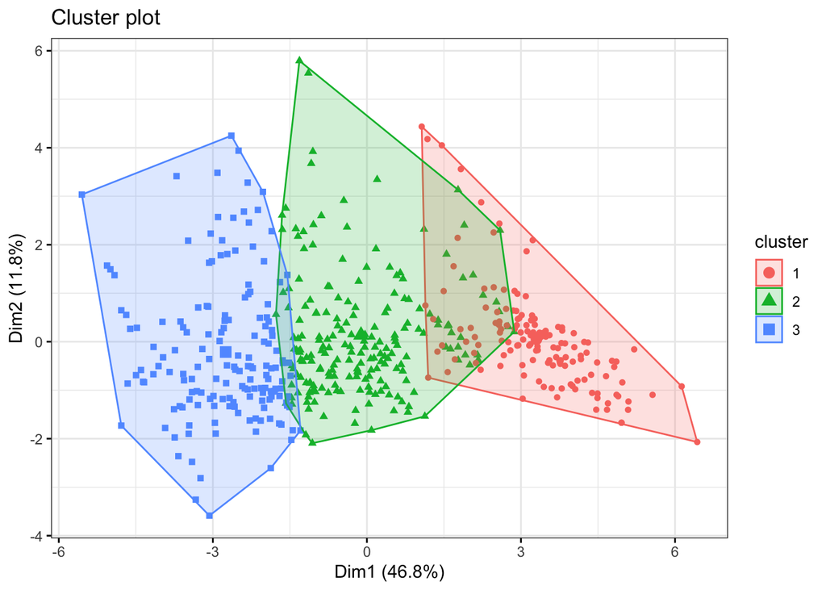

```r
# Visualize in 2D with principal components (from PCA, shows also percentage of
# variance explained).

factoextra::fviz_cluster(km, data = boston,
             #palette = c("#2E9FDF", "#00AFBB", "#E7B800"),
             geom = "point",
             ellipse.type = "convex",
             ggtheme = theme_bw())
```

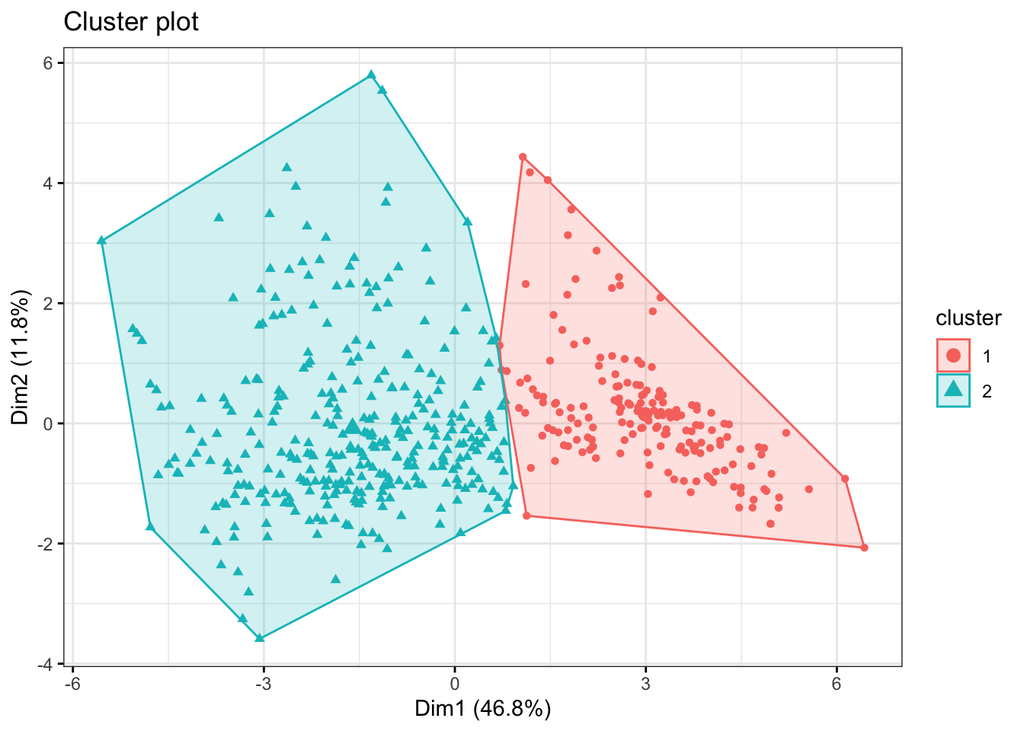

```r
km2 <- kmeans(boston, centers = 2)

factoextra::fviz_cluster(km2, data = boston,
             #palette = c("#2E9FDF", "#00AFBB", "#E7B800"),
             geom = "point",
             ellipse.type = "convex",
             ggtheme = theme_bw())
```

Two clusters overlap less than three, but clustering into three groups is not bad also.

## LDA on K-means clusters

```r
boston <- as.data.frame(scale(MASS::Boston))

km <- kmeans(boston, centers = 3)

boston$class <- km$cluster
```

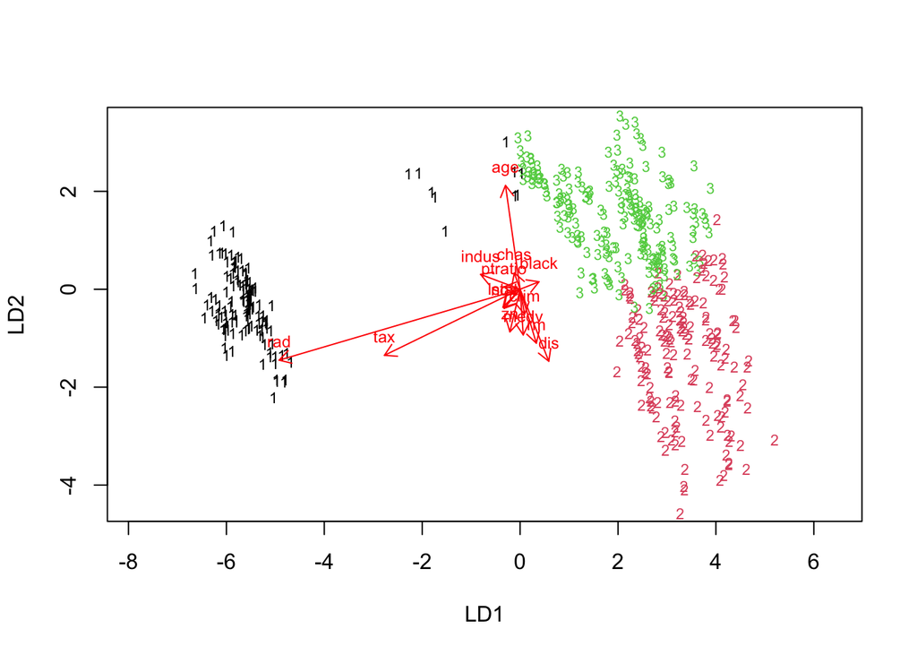

```r
# fit LDA
lda.fit.km <- lda(class ~ ., data = boston)

# plot the lda results
plot(lda.fit.km, dimen = 2, col = boston$class , pch = boston$class)
lda.arrows(lda.fit.km, myscale = 2.5)
```

`rad` is again imporant variable to separate a group from the others. This time also `tax` is similar in direction and magnitude as `rad`, which we expected from correlation analysis. `age` and `dis` separate clusters 2 and 3 stronger than the other variables.

## 3D plots

Reuse train set from above, follow instuctions of the course

```r
model_predictors <- dplyr::select(train, -crime)

# check the dimensions
dim(model_predictors)
```

```
## [1] 404  13
```

```r
dim(lda.fit$scaling)
```

```
## [1] 13  3
```

```r
# matrix multiplication
matrix_product <- as.matrix(model_predictors) %*% lda.fit$scaling
matrix_product <- as.data.frame(matrix_product)
```

```r
library(plotly)
plot_ly(x = matrix_product$LD1,
        y = matrix_product$LD2,
        z = matrix_product$LD3,
        type = "scatter3d", mode = "markers",
        color = train$crime)
```

[interactive chart not shown]

Plot the same with three k-means clusters

```r
km <- kmeans(train %>% select(-crime), centers = 3)

plot_ly(x = matrix_product$LD1,
        y = matrix_product$LD2,
        z = matrix_product$LD3,
        type = "scatter3d", mode = "markers",
        color = as.factor(km$cluster))
```

[interactive chart not shown]

Now it is more apparent how there might be three clusters. In both plots there is one `high` crime rate cluster, and the rest of data points form two clouds: a `low` cluster and a hypothetical `mid_to_high` cluster overlapping with the `low` class.

All in all, for prediction tasks, reliable models can be built for detecting `high` and `non-high` binary classes. For the three classes, uncertainty in the prediction between `low` and `mid_to_high` class will be higher.